# Big Data Bowl 23

Jack Hopper

2023-01-13

# Big Data Bowl 2023

For the 2023 Big Data Bowl, I decided to look at pre-snap data to determine a baseline model for predicting whether a lineman will be beat by a defender on the play. While there is a very rich set of quantitative & eye-test data that could supplement the analysis, I am curious: can we guess if a lineman will have a negative outcome based only on what we see pre-snap? In other words, I’m going to do a baseline analysis that includes only the basic descriptions about a lineman and his opponent – height, weight, as well as some info about the play type (ie offensive formation, which down it is, and basic pass coverage) – and see how ‘accurately’ we can predict whether or not the lineman will successfully block his defender or not.

To start, we will load in the provided data.

```r
library(tidyverse)

games <- read_csv("games.csv")
pffScoutingData <- read_csv("pffScoutingData.csv")
players <- read_csv("players.csv")
plays <- read_csv("plays.csv")
week1 <- read_csv("week1.csv")
week2 <- read_csv("week2.csv")
week3 <- read_csv("week3.csv")
week4 <- read_csv("week4.csv")
week5 <- read_csv("week5.csv")
week6 <- read_csv("week6.csv")
week7 <- read_csv("week7.csv")
week8 <- read_csv("week8.csv")

all_weeks <- bind_rows(week1, week2, week3, week4, week5, week6, week7, week8)

##Create unique ID for events -- combination of game & play
all_weeks$eventId <- paste0(all_weeks$gameId, all_weeks$playId)
```

#### Create baseline dataset on linemen movement

```r
linemen_events <- all_weeks %>%
  left_join(y = players, by = "nflId") %>%
  filter(officialPosition == "C" | officialPosition == "G" | officialPosition == "T") %>%
  select(-collegeName)

glimpse(linemen_events)
```

```
## Rows: 1,811,820
## Columns: 22
## $ gameId           <dbl> 2021090900, 2021090900, 2021090900, 2021090900, 20210…
## $ playId           <dbl> 97, 97, 97, 97, 97, 97, 97, 97, 97, 97, 97, 97, 97, 9…
## $ nflId            <dbl> 40151, 40151, 40151, 40151, 40151, 40151, 40151, 4015…
## $ frameId          <dbl> 1, 2, 3, 4, 5, 6, 7, 8, 9, 10, 11, 12, 13, 14, 15, 16…
## $ time             <dttm> 2021-09-10 00:26:31, 2021-09-10 00:26:31, 2021-09-10…
## $ jerseyNumber     <dbl> 66, 66, 66, 66, 66, 66, 66, 66, 66, 66, 66, 66, 66, 6…
## $ team             <chr> "TB", "TB", "TB", "TB", "TB", "TB", "TB", "TB", "TB",…
## $ playDirection    <chr> "right", "right", "right", "right", "right", "right",…
## $ x                <dbl> 42.18, 42.16, 42.15, 42.15, 42.14, 42.10, 42.03, 41.9…
## $ y                <dbl> 23.97, 23.97, 23.97, 23.98, 23.99, 24.02, 24.06, 24.1…
## $ s                <dbl> 0.00, 0.00, 0.01, 0.06, 0.18, 0.51, 0.79, 1.00, 1.17,…
## $ a                <dbl> 0.00, 0.00, 0.21, 0.63, 1.02, 1.98, 2.13, 1.84, 1.35,…
## $ dis              <dbl> 0.01, 0.02, 0.01, 0.01, 0.02, 0.06, 0.07, 0.09, 0.11,…
## $ o                <dbl> 45.36, 45.36, 46.28, 46.28, 47.50, 48.28, 53.21, 57.0…
## $ dir              <dbl> 206.92, 216.20, 275.73, 308.29, 317.31, 308.34, 305.0…
## $ event            <chr> "None", "None", "None", "None", "None", "ball_snap", …
## $ eventId          <chr> "202109090097", "202109090097", "202109090097", "2021…
## $ height           <chr> "6-4", "6-4", "6-4", "6-4", "6-4", "6-4", "6-4", "6-4…
## $ weight           <dbl> 319, 319, 319, 319, 319, 319, 319, 319, 319, 319, 319…
## $ birthDate        <chr> "1991-05-27", "1991-05-27", "1991-05-27", "1991-05-27…
## $ officialPosition <chr> "C", "C", "C", "C", "C", "C", "C", "C", "C", "C", "C"…
## $ displayName      <chr> "Ryan Jensen", "Ryan Jensen", "Ryan Jensen", "Ryan Je…
```

This dataset gives us a lot of information on the specific movements of a player. But let’s see if we can supplement this with player statistics.

First let’s examine the players dataset

```r
glimpse(players)
```

```
## Rows: 1,679
## Columns: 7
## $ nflId            <dbl> 25511, 28963, 29550, 29851, 30078, 30842, 30869, 3308…
## $ height           <chr> "6-4", "6-5", "6-4", "6-2", "6-2", "6-6", "6-7", "6-4…
## $ weight           <dbl> 225, 240, 328, 225, 228, 267, 330, 217, 315, 175, 300…
## $ birthDate        <chr> "1977-08-03", "1982-03-02", "1982-01-22", "1983-12-02…
## $ collegeName      <chr> "Michigan", "Miami, O.", "Arkansas", "California", "H…
## $ officialPosition <chr> "QB", "QB", "T", "QB", "QB", "TE", "T", "QB", "T", "W…
## $ displayName      <chr> "Tom Brady", "Ben Roethlisberger", "Jason Peters", "A…
```

```r
players %>%
  filter(is.na(birthDate)) #%>%
```

```
## # A tibble: 232 × 7
##    nflId height weight birthDate collegeName     officialPosition displayName
##    <dbl> <chr>   <dbl> <chr>     <chr>           <chr>            <chr>
##  1 52427 6-0       195 <NA>      Ohio State      CB               Damon Arnette
##  2 52430 6-3       192 <NA>      Louisiana State WR               Justin Jeffer…
##  3 52459 6-2       207 <NA>      Alabama         CB               Trevon Diggs
##  4 52464 6-7       310 <NA>      Alabama         NT               Raekwon Davis
##  5 52504 6-7       328 <NA>      <NA>            T                Lucas Niang
##  6 52539 6-2       308 <NA>      Louisiana State NT               Rashard Lawre…
##  7 52566 6-1       201 <NA>      <NA>            CB               Bryce Hall
##  8 52585 6-2       255 <NA>      Michigan        DE               Michael Danna
##  9 52587 6-3       265 <NA>      Utah            DE               Bradlee Anae
## 10 52592 6-1       333 <NA>      Baylor          DT               Bravvion Roy
## # … with 222 more rows
## # ℹ Use `print(n = ...)` to see more rows
```

It looks like there are some players with missing birthdays in the players dataset. This is important because we will attempt to attach player age to our linemen table later. It looks like these missing players are mostly rookies. So, let’s infer their birthdate: I’ll assign them all 1/1/1998 for now, then look at linemen only and create a table for all players to join when they are the ‘defender’ being blocked by the lineman.

```r
players <- players %>%
  mutate(birthDate = ifelse(is.na(birthDate), "1998-01-01", birthDate))

linemen <- players %>%
  filter(officialPosition == "C" | officialPosition == "G" | officialPosition == "T")

opposition <- players %>%
  mutate(opposing_weight = weight,
         opposing_height = height,
         opposing_position = officialPosition)
```

Now we can look at the PFF data, which includes information on whether a player was ‘beaten’ by their defender on the play.

```r
linemen_scouting <- pffScoutingData %>%
  mutate(eventId = paste0(pffScoutingData$gameId, pffScoutingData$playId)) %>%
  filter(nflId %in% linemen$nflId)
```

And we can supplement this data with other information about each player, as below.

```r
###Add player stats to scouting data
#First basic stats
linemen_scouting <- linemen_scouting %>%
  left_join(select(players, nflId, weight, height), by = "nflId")
#Then player age
player_age <- all_weeks %>%
  left_join(y = players, by = "nflId") %>%
  select(-collegeName) %>%
  mutate(player_age = as.numeric(as.Date(time) - as.Date(birthDate))/365.25) %>%
  select(eventId, nflId, player_age) %>%
  group_by(eventId, nflId) %>%
  summarise(player_age = mean(player_age)) %>%
  ungroup()
#We can simplify this dataset, as player age won't vary dramatically week to week
player_age <- player_age %>%
  group_by(nflId) %>%
  summarize(player_age = mean(player_age))

#And finish it off...
linemen_scouting <- linemen_scouting %>%
  inner_join(player_age, by = c("nflId"))

#Remove extraneous columns (fields for defensive players)
linemen_scouting <- linemen_scouting %>%
  select(-pff_hit, -pff_hurry, -pff_sack)

#Remove miscellaneous positions
linemen_scouting <- linemen_scouting %>%
  filter(pff_positionLinedUp %in% c("C", "LG", "RG", "RT", "LT"))
```

Let’s visualize our data.

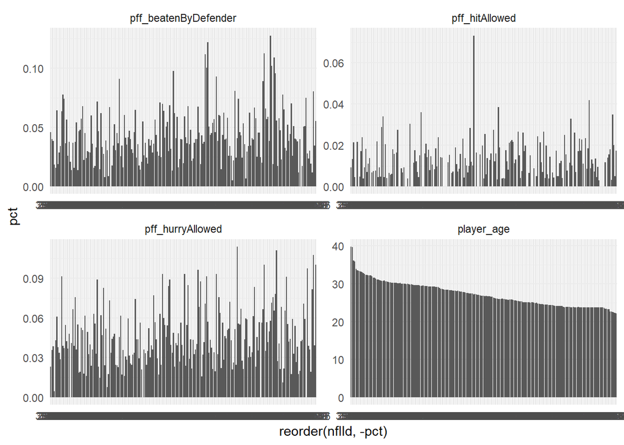

```r
##### EDA on linemen data
#Exploring how often a player allows an event to happen
linemen_scouting %>%
  group_by(nflId) %>%
  summarize(obs = n(),
            pff_beatenByDefender = mean(pff_beatenByDefender),
            pff_hitAllowed = mean(pff_hitAllowed),
            pff_hurryAllowed = mean(pff_hurryAllowed),
            player_age = mean(player_age)) %>%
  filter(obs >= 40) %>% #Limit data to those with 'enough' observations
  select(-obs) %>%
  mutate(nflId = as.character(nflId)) %>%
  pivot_longer(-nflId, names_to = "metric", values_to = "pct") %>%
  group_by(metric) %>%
  arrange(pct) %>%
  ggplot(aes(x = reorder(nflId, -pct), y = pct)) +
  geom_col() +
  facet_wrap(~metric, scales = 'free') +
  theme_minimal()
```

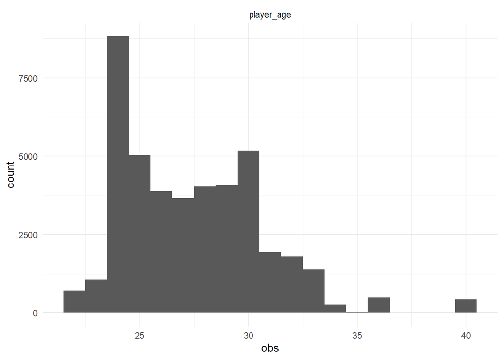

```r
##Histogram for player age
linemen_scouting %>%
  select(nflId, player_age) %>%
  mutate(nflId = as.character(nflId)) %>%
  pivot_longer(-nflId, names_to = "metric", values_to = "obs") %>%
  ggplot(aes(x = obs)) +
  geom_histogram(binwidth = 1) +
  facet_wrap(~metric, scales = 'free') +
  theme_minimal()
```

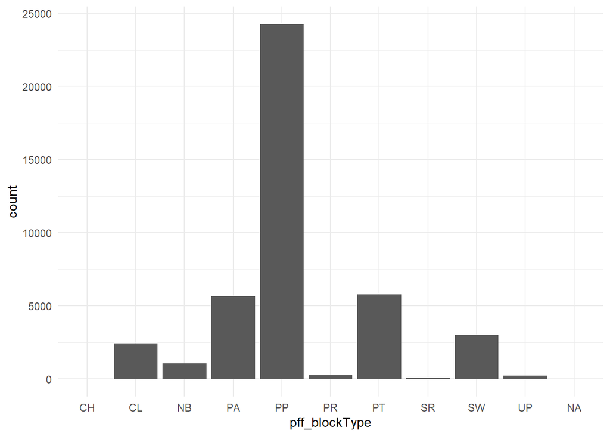

```r
#Count of block type
ggplot(linemen_scouting, aes(x = pff_blockType)) +
  geom_bar() +
  theme_minimal()
```

```r
#Explore player roles
linemen_scouting %>%
  group_by(pff_positionLinedUp) %>%
  count() %>%
  arrange(desc(n))
```

```
## # A tibble: 5 × 2
## # Groups:   pff_positionLinedUp [5]
##   pff_positionLinedUp     n
##   <chr>               <int>
## 1 C                    8557
## 2 LG                   8557
## 3 RG                   8557
## 4 RT                   8555
## 5 LT                   8553
```

#### Adding features about the defense

Now that we have a sense of our data, we can start adding additional features and coming up with a model-ready dataset.

```r
events <- linemen_scouting

events <- events %>%
  left_join(select(opposition, nflId, opposing_weight, opposing_height, opposing_position), by = c("pff_nflIdBlockedPlayer" = "nflId"))

#Then age
events <- events %>%
  left_join(player_age, by = c("pff_nflIdBlockedPlayer" = "nflId")) %>%
  rename(player_age = player_age.x,
         opposition_age = player_age.y)

#Remove unnecessary columns
events %>%
  select(-pff_role, -pff_backFieldBlock)
```

```
## # A tibble: 42,779 × 18
##      gameId playId nflId pff_p…¹ pff_b…² pff_h…³ pff_h…⁴ pff_s…⁵ pff_n…⁶ pff_b…⁷
##       <dbl>  <dbl> <dbl> <chr>     <dbl>   <dbl>   <dbl>   <dbl>   <dbl> <chr>
##  1   2.02e9     97 40151 C             0       0       0       0   44955 SW
##  2   2.02e9     97 42377 LT            0       0       1       0   42403 PP
##  3   2.02e9     97 42404 LG            0       0       0       0   44955 PP
##  4   2.02e9     97 46163 RG            0       0       1       0   53441 SW
##  5   2.02e9     97 52421 RT            0       0       1       0   53441 PP
##  6   2.02e9    137 37082 LT            0       0       0       0   35454 PT
##  7   2.02e9    137 42654 RT            0       0       0       0   40074 PP
##  8   2.02e9    137 46119 LG            0       0       0       0   35441 SW
##  9   2.02e9    137 47873 RG            0       0       0       0   46081 PP
## 10   2.02e9    137 52554 C             0       0       0       0   35441 PP
## # … with 42,769 more rows, 8 more variables: eventId <chr>, weight <dbl>,
## #   height <chr>, player_age <dbl>, opposing_weight <dbl>,
## #   opposing_height <chr>, opposing_position <chr>, opposition_age <dbl>, and
## #   abbreviated variable names ¹pff_positionLinedUp, ²pff_beatenByDefender,
## #   ³pff_hitAllowed, ⁴pff_hurryAllowed, ⁵pff_sackAllowed,
## #   ⁶pff_nflIdBlockedPlayer, ⁷pff_blockType
## # ℹ Use `print(n = ...)` to see more rows, and `colnames()` to see all variable names
```

One interesting thing we could add as a feature would be a way to measure the number of nearby defenders. Let’s see if we can do that.

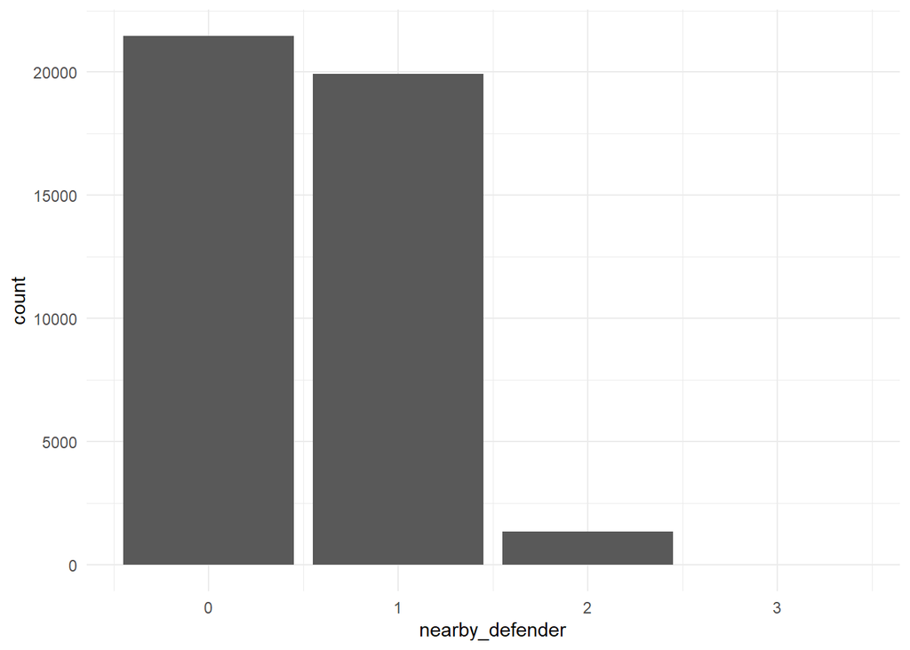

```r
###Step 1: Isolate play data for snaps for defensive players & linemen positions

defensive_snaps <- all_weeks %>%
  filter(event == 'ball_snap') %>%
  left_join(players, by = "nflId") %>%
  select(-collegeName, -displayName, -jerseyNumber, -playDirection, -birthDate) %>%
  filter(officialPosition %in% c("DE", "MLB", "CB", "SS", "OLB", "DT", "ILB", "NT", "FS", "LB", "DB")) %>%
  mutate(defensive_x = x,
         defensive_y = y) %>%
  select(gameId, playId, nflId, defensive_x, defensive_y)

linemen_snaps <- all_weeks %>%
  filter(event == 'ball_snap') %>%
  left_join(players, by = "nflId") %>%
  select(-collegeName, -displayName, -jerseyNumber, -playDirection, -birthDate) %>%
  filter(officialPosition %in% c("C", "G", "T")) %>%
  mutate(offensive_x = x,
         offensive_y = y) %>%
  select(gameId, playId, nflId, offensive_x, offensive_y)


###Step 2: Join defense & offense snaps to see where each defender is for each lineman
snaps <- linemen_snaps %>%
  left_join(defensive_snaps, by = c("gameId" = "gameId", "playId" = "playId"))

###Step 3: Flag each entry as meeting or not meeting the threshold for x & y distance
#Define the thresholds
x_threshold <- 2
y_threshold <- 1.5

#Do the flagging
snaps <- snaps %>%
  mutate(near_x = if_else(abs(offensive_x - defensive_x) <= x_threshold, 1, 0),
         near_y = if_else(abs(offensive_y - defensive_y) <= y_threshold, 1, 0),
         nearby_defender = if_else(near_x == 1 & near_y == 1, 1, 0))

###Step 4: Count up the number of nearby defenders for each lineman per play
#First - validate that the thresholds we set show reasonable results
snaps %>%
  group_by(gameId, playId, nflId.x) %>%
  summarize(across(c(nearby_defender, near_x, near_y), sum)) %>%
  ggplot() +
    geom_bar(aes(x = nearby_defender)) +
    theme_minimal()
```

```r
#Then apply the math to the df
snaps <- snaps %>%
  group_by(gameId, playId, nflId.x) %>%
  summarize(across(c(nearby_defender), sum))
###Step 5: Re-join to the main events table
events <- events %>%
  left_join(snaps, by = c("nflId" = "nflId.x", "gameId" = "gameId", "playId" = "playId"))

### Add info on the play itself
#First define what we want to append to the events df
plays_slim <- plays %>%
  mutate(eventId = paste0(gameId, playId)) %>%
  select(eventId, quarter, down, yardsToGo, possessionTeam, yardlineSide, yardlineNumber,
         offenseFormation, defendersInBox, pff_passCoverage) %>%
  mutate(yards_from_endzone = case_when(possessionTeam == yardlineSide ~ (50-yardlineNumber) + 50,
                                   TRUE ~ yardlineNumber))

#Then add it
events <- events %>%
  left_join(plays_slim, by = "eventId")
```

#### Determining the outcome variable

Now we can come up with our outcome variable: if a lineman is beaten by a defender in any way – ‘beaten’, ‘hurry allowed,’ ‘hit allowed,’ or ‘sack allowed,’ we’ll consider them all to be the same bad outcome. If a lineman didn’t allow a hit, he will get a score of 0. So not getting beat = 0, getting beat = 1.

```r
events <- events %>%
  mutate(event_score = case_when(pff_beatenByDefender == 1 ~ 1,
                                 pff_hurryAllowed == 1 ~ 1,
                                 pff_hitAllowed == 1 ~ 1,
                                 pff_sackAllowed == 1 ~ 1,
                                 TRUE ~ 0)) %>%
  select(-pff_beatenByDefender, -pff_hurryAllowed, -pff_hitAllowed, -pff_sackAllowed)
```

Now we can create a model-ready dataset and ensure we aren’t missing data.

```r
mrd <- events %>%
  select(eventId, everything(), -gameId, -playId, -pff_role)

#install.packages("Amelia")
library(Amelia)
```

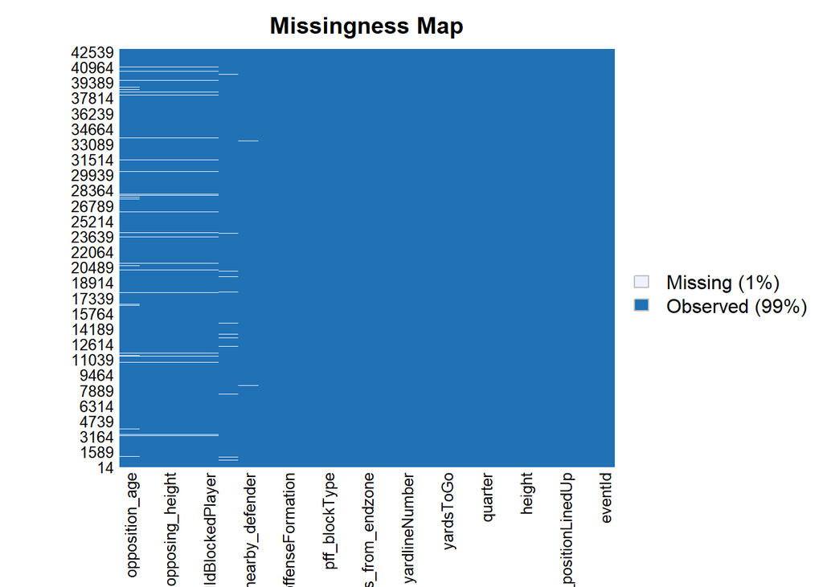

```r
missmap(mrd, main = "Missingness Map")
```

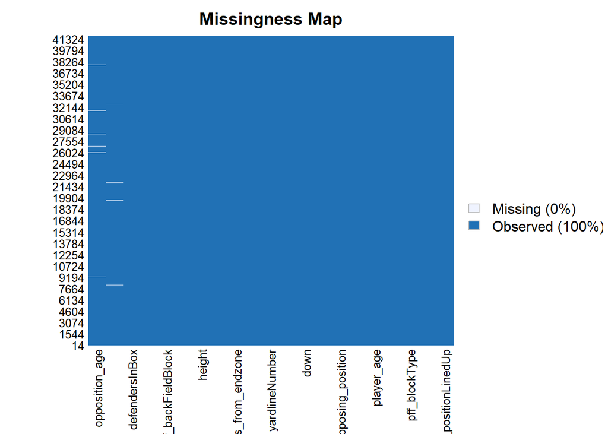

```r
#We should remove cases where opposing_position is missing
mrd <- mrd %>%
  filter(!is.na(opposing_position))

#Remove non-predictor/predicted columns
mrd <- mrd %>%
  select(-eventId, -nflId, -possessionTeam, -yardlineSide)

#Convert height fields to numeric
mrd <- mrd %>%
  separate(height, into = c("height_ft", "height_in"), sep = "-") %>%
  mutate_at(vars(height_ft, height_in), as.numeric) %>%
  mutate(height = 12*height_ft + height_in) %>%
  #Now move on top opposing players
  separate(opposing_height, into = c("opposing_height_ft", "opposing_height_in"), sep = "-") %>%
  mutate_at(vars(opposing_height_ft, opposing_height_in), as.numeric) %>%
  mutate(opposing_height = 12*opposing_height_ft + opposing_height_in) %>%
  select(-height_ft, -height_in, -opposing_height_ft, -opposing_height_in)

#Convert character fields to factor
mrd <- mrd %>%
  mutate_at(vars(pff_positionLinedUp, pff_blockType, opposing_position,
                 quarter, down, offenseFormation, pff_passCoverage, event_score), as.factor)

#One more missingness map
missmap(mrd, main = "Missingness Map")
```

That was a lot of pre-processing: let’s take one final look at our dataset before modeling it.

```r
str(mrd)
```

```
## tibble [41,684 × 21] (S3: tbl_df/tbl/data.frame)
##  $ pff_positionLinedUp   : Factor w/ 5 levels "C","LG","LT",..: 1 3 2 4 5 3 5 2 4 1 ...
##  $ pff_nflIdBlockedPlayer: num [1:41684] 44955 42403 44955 53441 53441 ...
##  $ pff_blockType         : Factor w/ 9 levels "CH","CL","PA",..: 8 4 4 8 4 6 4 8 4 4 ...
##  $ pff_backFieldBlock    : num [1:41684] 0 0 0 0 0 0 0 0 0 0 ...
##  $ weight                : num [1:41684] 319 338 307 305 322 320 320 298 308 320 ...
##  $ player_age            : num [1:41684] 30.4 28.3 28.5 26.7 22.7 ...
##  $ opposing_weight       : num [1:41684] 297 255 297 245 245 275 281 313 347 313 ...
##  $ opposing_position     : Factor w/ 12 levels "CB","DE","DT",..: 2 2 2 10 10 2 2 2 9 2 ...
##  $ opposition_age        : num [1:41684] 27.8 28.9 27.8 23.8 23.8 ...
##  $ nearby_defender       : num [1:41684] 1 0 2 0 0 1 0 0 1 1 ...
##  $ quarter               : Factor w/ 5 levels "1","2","3","4",..: 1 1 1 1 1 1 1 1 1 1 ...
##  $ down                  : Factor w/ 5 levels "0","1","2","3",..: 4 4 4 4 4 2 2 2 2 2 ...
##  $ yardsToGo             : num [1:41684] 2 2 2 2 2 10 10 10 10 10 ...
##  $ yardlineNumber        : num [1:41684] 33 33 33 33 33 2 2 2 2 2 ...
##  $ offenseFormation      : Factor w/ 7 levels "EMPTY","I_FORM",..: 5 5 5 5 5 1 1 1 1 1 ...
##  $ defendersInBox        : num [1:41684] 6 6 6 6 6 6 6 6 6 6 ...
##  $ pff_passCoverage      : Factor w/ 12 levels "2-Man","Bracket",..: 4 4 4 4 4 6 6 6 6 6 ...
##  $ yards_from_endzone    : num [1:41684] 67 67 67 67 67 98 98 98 98 98 ...
##  $ event_score           : Factor w/ 2 levels "0","1": 1 2 1 2 2 1 1 1 1 1 ...
##  $ height                : num [1:41684] 76 78 76 78 77 77 76 77 77 75 ...
##  $ opposing_height       : num [1:41684] 75 77 75 75 75 77 78 76 76 76 ...
```

### Part II: Modeling

Throughout my analysis I tried looking at both a simple decision tree and a more complex random forest methodology. Since the random forest does better, I will describe this process below. The goal of this analysis is to see ‘how far’ simple pre-snap statistics can take us when it comes to predicting whether or not a lineman will give up a pressure or sack on a given pass play. I don’t expect he model to be extremelye accurate because this dataset does not take into account ‘eye test’ metrics such as protection moves used, type of pass play called, historical performance of players, etc.

#### Setting up the Model

First, we have to separate our data into a training & test set.

```r
library(caret)
library(performanceEstimation) #For SMOTE
RNGkind(sample.kind = "Rounding")
set.seed(1234)
sample_set <- createDataPartition(y = mrd$event_score, p = .75, list = FALSE)
outcome_train <- mrd[sample_set, ]
outcome_test <- mrd[-sample_set, ]

colnames(outcome_train) <- make.names(colnames(outcome_train))
```

One thing we need to look for is whether or not the two classes in our outcome variable are represented equally; otherwise, the model won’t be able to figure out how to predict the minority class. Let’s examine this below.

```r
#Are classes even?
round(prop.table(table(outcome_train$event_score)),2)
```

```
##
##    0    1
## 0.89 0.11
```

We can see the two classes are not close to equal – only 11% of the training data is of type 1 (ie bad outcome). To correct for this, we can make synthetic training data using the ‘SMOTE’ (synthetic minority oversampling technique) method.

```r
#Need to make synthetic data to even up the classes
outcome_train <- smote(event_score ~ ., data.frame(outcome_train), perc.over = 2, k = 5, perc.under = 2)
round(prop.table(table(outcome_train$event_score)),2) #Now, the data is balanced, moreso
```

```
##
##    0    1
## 0.57 0.43
```

#### Model Building & Testing

While it isn’t perfect, the classes are much more closely matched now. We can proceed with model-building.

```r
library(randomForest)
modelLookup("rf")
```

```
##   model parameter                         label forReg forClass probModel
## 1    rf      mtry #Randomly Selected Predictors   TRUE     TRUE      TRUE
```

```r
#There is only one hyperparameter - mtry (the max # of features sampled within a tree)
grid <- expand.grid(mtry = seq(from = 4, to = 10, by = 1))
```

Random forest takes one hyperparameter, called ‘mtry,’ and we can iterate through the value of this with a grid search. Now we can build the model. Note that I am picking the best model based on kappa rather than pure accuracy, which tracks accuracy after correcting for the likelihood of picking the right model at random – a necessary adjustment given the lower naturally-occurring instances of the minority class here.

```r
#Train the model
RNGkind(sample.kind = "Rounding")
set.seed(1234)

rf_mod <- train(
  event_score ~ .,
  data = outcome_train,
  method = "rf",
  na.action = na.omit,
  metric = "Kappa",
  trControl = trainControl(method = "boot632", number = 3),
  tuneGrid = grid
)

rf_mod
```

```
## Random Forest
##
## 23254 samples
##    20 predictor
##     2 classes: '0', '1'
##
## No pre-processing
## Resampling: Bootstrapped (3 reps)
## Summary of sample sizes: 22891, 22891, 22891
## Resampling results across tuning parameters:
##
##   mtry  Accuracy   Kappa
##    4    0.8788932  0.7433587
##    5    0.8979169  0.7832456
##    6    0.9027483  0.7932038
##    7    0.9034358  0.7947281
##    8    0.9046269  0.7972129
##    9    0.9037551  0.7953684
##   10    0.9049434  0.7978664
##
## Kappa was used to select the optimal model using the largest value.
## The final value used for the model was mtry = 10.
```

#### Evaluating performance

And we can evaluate performance on the test set.

```r
outcome_pred <- predict(rf_mod, outcome_test, type = "raw")
head(outcome_pred)
```

```
## [1] 1 0 0 0 0 0
## Levels: 0 1
```

```r
outcome_pred_table <- table(outcome_test[complete.cases(outcome_test), ]$event_score, outcome_pred)

print(sum(diag(outcome_pred_table)) / nrow(outcome_test))
```

```
## [1] 0.8596929
```

This analysis shows that our model is 86% accurate in our test set. For a final check, we can look at the confusion matrix to show false positives or negatives.

```r
outcome_pred_table
```

```
##    outcome_pred
##        0    1
##   0 8895  247
##   1 1028   63
```

Using this we can see that the model is still missing a lot of instances where the player was beat, as the model was not able to guess accurately. Still, in 86% of cases the model was able to accurately predict the outcome of the matchup. In addition, the model is catching a few cases where a lineman got beat.

## Conclusion

Overall, the model isn’t quite good enough to be able to be used at scale… but it does at least illustrate that you can get a basic sense of the likelihood of success or failure for a lineman on a given play.

Some good next steps for this analysis would be to do any of the following: supplement the analysis with more descriptive features to lead to more predictive accuracy, particularly for the ‘1’ outcome (minority class); continue the analysis by interpreting which features are most important in our model; and use the model to analyze a specific player & situation of interest.

Thanks for reading!